# ML2 -- mohit final 1

```python
import pandas as pd
import numpy as np

from matplotlib import pyplot as plt
%matplotlib inline

import seaborn as sns
```

```python
diab=pd.read_table("diabetes.csv",sep=",")
```

```python
print diab.shape
print diab.info()
```

```
(768, 9)
<class 'pandas.core.frame.DataFrame'>
RangeIndex: 768 entries, 0 to 767
Data columns (total 9 columns):
Pregnancies                 768 non-null int64
Glucose                     768 non-null int64
BloodPressure               768 non-null int64
SkinThickness               768 non-null int64
Insulin                     768 non-null int64
BMI                         768 non-null float64
DiabetesPedigreeFunction    768 non-null float64
Age                         768 non-null int64
Outcome                     768 non-null int64
dtypes: float64(2), int64(7)
memory usage: 54.1 KB
None
```

```python
diab.isnull().sum().any()
```

```
False
```

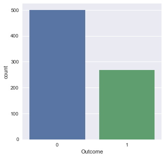

```python
plt.figure(figsize=(5,5))
sns.countplot(data=diab, x="Outcome")
```

```python
print diab[diab.Outcome==1].shape
print diab[diab.Outcome==0].shape
```

```
(268, 9)
(500, 9)
```

```python
def var_summary(x):
    return pd.Series([x.count(), x.isnull().sum(), x.sum(), x.mean(), x.median(),  x.std(), x.var(), x.min(), x.dropna().quantile(0.01), x.dropna().quantile(0.05),x.dropna().quantile(0.10),x.dropna().quantile(0.25),x.dropna().quantile(0.50),x.dropna().quantile(0.75), x.dropna().quantile(0.90),x.dropna().quantile(0.95), x.dropna().quantile(0.99),x.max()],
                  index=['N', 'NMISS', 'SUM', 'MEAN','MEDIAN', 'STD', 'VAR', 'MIN', 'P1' , 'P5' ,'P10' ,'P25' ,'P50' ,'P75' ,'P90' ,'P95' ,'P99' ,'MAX'])
```

```python
diab.apply(lambda x:var_summary(x)).T
```

|  | N | NMISS | SUM | MEAN | MEDIAN | STD | VAR | MIN | P1 | P5 | P10 | P25 | P50 | P75 | P90 | P95 | P99 | MAX |
| --- | --- | --- | --- | --- | --- | --- | --- | --- | --- | --- | --- | --- | --- | --- | --- | --- | --- | --- |
| Pregnancies | 768.0 | 0.0 | 2953.000 | 3.845052 | 3.0000 | 3.369578 | 11.354056 | 0.000 | 0.00000 | 0.00000 | 0.000 | 1.00000 | 3.0000 | 6.00000 | 9.0000 | 10.00000 | 13.00000 | 17.00 |
| Glucose | 768.0 | 0.0 | 92847.000 | 120.894531 | 117.0000 | 31.972618 | 1022.248314 | 0.000 | 57.00000 | 79.00000 | 85.000 | 99.00000 | 117.0000 | 140.25000 | 167.0000 | 181.00000 | 196.00000 | 199.00 |
| BloodPressure | 768.0 | 0.0 | 53073.000 | 69.105469 | 72.0000 | 19.355807 | 374.647271 | 0.000 | 0.00000 | 38.70000 | 54.000 | 62.00000 | 72.0000 | 80.00000 | 88.0000 | 90.00000 | 106.00000 | 122.00 |
| SkinThickness | 768.0 | 0.0 | 15772.000 | 20.536458 | 23.0000 | 15.952218 | 254.473245 | 0.000 | 0.00000 | 0.00000 | 0.000 | 0.00000 | 23.0000 | 32.00000 | 40.0000 | 44.00000 | 51.33000 | 99.00 |
| Insulin | 768.0 | 0.0 | 61286.000 | 79.799479 | 30.5000 | 115.244002 | 13281.180078 | 0.000 | 0.00000 | 0.00000 | 0.000 | 0.00000 | 30.5000 | 127.25000 | 210.0000 | 293.00000 | 519.90000 | 846.00 |
| BMI | 768.0 | 0.0 | 24570.300 | 31.992578 | 32.0000 | 7.884160 | 62.159984 | 0.000 | 0.00000 | 21.80000 | 23.600 | 27.30000 | 32.0000 | 36.60000 | 41.5000 | 44.39500 | 50.75900 | 67.10 |
| DiabetesPedigreeFunction | 768.0 | 0.0 | 362.401 | 0.471876 | 0.3725 | 0.331329 | 0.109779 | 0.078 | 0.09468 | 0.14035 | 0.165 | 0.24375 | 0.3725 | 0.62625 | 0.8786 | 1.13285 | 1.69833 | 2.42 |
| Age | 768.0 | 0.0 | 25529.000 | 33.240885 | 29.0000 | 11.760232 | 138.303046 | 21.000 | 21.00000 | 21.00000 | 22.000 | 24.00000 | 29.0000 | 41.00000 | 51.0000 | 58.00000 | 67.00000 | 81.00 |
| Outcome | 768.0 | 0.0 | 268.000 | 0.348958 | 0.0000 | 0.476951 | 0.227483 | 0.000 | 0.00000 | 0.00000 | 0.000 | 0.00000 | 0.0000 | 1.00000 | 1.0000 | 1.00000 | 1.00000 | 1.00 |

```python
def outlier_handline(x):
    x=x.clip_upper(x.quantile(.99))
    x=x.clip_lower(x.quantile(.01))
    return x
```

```python
diab_bck = diab
```

```python
diab=diab.apply(lambda x:outlier_handline(x))
```

```python
diab.apply(lambda x:var_summary(x)).T
```

|  | N | NMISS | SUM | MEAN | MEDIAN | STD | VAR | MIN | P1 | P5 | P10 | P25 | P50 | P75 | P90 | P95 | P99 | MAX |
| --- | --- | --- | --- | --- | --- | --- | --- | --- | --- | --- | --- | --- | --- | --- | --- | --- | --- | --- |
| Pregnancies | 768.0 | 0.0 | 2945.00000 | 3.834635 | 3.0000 | 3.336808 | 11.134288 | 0.00000 | 0.000000 | 0.00000 | 0.000 | 1.00000 | 3.0000 | 6.00000 | 9.0000 | 10.00000 | 13.000000 | 13.00000 |
| Glucose | 768.0 | 0.0 | 93137.00000 | 121.272135 | 117.0000 | 30.807518 | 949.103160 | 57.00000 | 57.000000 | 79.00000 | 85.000 | 99.00000 | 117.0000 | 140.25000 | 167.0000 | 181.00000 | 196.000000 | 196.00000 |
| BloodPressure | 768.0 | 0.0 | 53033.00000 | 69.053385 | 72.0000 | 19.243340 | 370.306142 | 0.00000 | 0.000000 | 38.70000 | 54.000 | 62.00000 | 72.0000 | 80.00000 | 88.0000 | 90.00000 | 106.000000 | 106.00000 |
| SkinThickness | 768.0 | 0.0 | 15692.64000 | 20.433125 | 23.0000 | 15.646206 | 244.803750 | 0.00000 | 0.000000 | 0.00000 | 0.000 | 0.00000 | 23.0000 | 32.00000 | 40.0000 | 44.00000 | 51.108900 | 51.33000 |
| Insulin | 768.0 | 0.0 | 60368.20000 | 78.604427 | 30.5000 | 109.425722 | 11973.988664 | 0.00000 | 0.000000 | 0.00000 | 0.000 | 0.00000 | 30.5000 | 127.25000 | 210.0000 | 293.00000 | 513.267000 | 519.90000 |
| BMI | 768.0 | 0.0 | 24526.87200 | 31.936031 | 32.0000 | 7.712781 | 59.486986 | 0.00000 | 0.000000 | 21.80000 | 23.600 | 27.30000 | 32.0000 | 36.60000 | 41.5000 | 44.39500 | 50.250470 | 50.75900 |
| DiabetesPedigreeFunction | 768.0 | 0.0 | 359.77808 | 0.468461 | 0.3725 | 0.314849 | 0.099130 | 0.09468 | 0.095564 | 0.14035 | 0.165 | 0.24375 | 0.3725 | 0.62625 | 0.8786 | 1.13285 | 1.698109 | 1.69833 |
| Age | 768.0 | 0.0 | 25502.00000 | 33.205729 | 29.0000 | 11.645318 | 135.613422 | 21.00000 | 21.000000 | 21.00000 | 22.000 | 24.00000 | 29.0000 | 41.00000 | 51.0000 | 58.00000 | 67.000000 | 67.00000 |
| Outcome | 768.0 | 0.0 | 268.00000 | 0.348958 | 0.0000 | 0.476951 | 0.227483 | 0.00000 | 0.000000 | 0.00000 | 0.000 | 0.00000 | 0.0000 | 1.00000 | 1.0000 | 1.00000 | 1.000000 | 1.00000 |

### Brief analysis of data

[output not shown]

[figure not shown]

```python
plt.figure(figsize=(40,40))
diab.hist(bins=20, edgecolor='b')
```

[output not shown]

[figure not shown]

```python
diab1=diab[diab.Outcome==1]
diab1.hist(bins=20, edgecolor = 'B')
```

[figure not shown]

```python
sns.pairplot(data=diab, hue="Outcome",diag_kind='kde')
plt.show()
```

### Observation

> - Diagonal shows distribution of dataset with density plot
> - Scatter plot shows the relationship b/w each and every vaible or feature taken [airwise.

Looking at the scatter-plots, we can say that no two attributes are able to clearly seperate the two outcome-class instances.

### Predective Modelling

Lets go with the Predective Modelling

```python
from sklearn.linear_model import LogisticRegression
from sklearn import svm
from sklearn.neighbors import KNeighborsClassifier
from sklearn.tree import DecisionTreeClassifier
from sklearn.cross_validation import KFold

from sklearn.cross_validation import train_test_split

from sklearn import metrics

import warnings
warnings.filterwarnings('ignore')
```

### Stratification

When we split the dataset into train and test datasets, the split is completely random. Thus the instances of each class label or outcome in the train or test datasets is random. Thus we may have many instances of class 1 in training data and less instances of class 2 in the training data. So during classification, we may have accurate predictions for class1 but not for class2. Thus we stratify the data, so that we have proportionate data for all the classes in both the training and testing data.

```python
feature_column=diab.columns.difference(['Outcome'])
feature_column
```

```
Index([u'Age', u'BMI', u'BloodPressure', u'DiabetesPedigreeFunction',
       u'Glucose', u'Insulin', u'Pregnancies', u'SkinThickness'],
      dtype='object')
```

```python
train_x, test_x, train_y,test_y=train_test_split(diab[feature_column], diab.Outcome, random_state=123, test_size=0.3, stratify=diab['Outcome'])
```

```python
print 'Train size is x : ', train_x.shape , 'and y is : ', train_y.shape
print 'Test size is x : ', test_x.shape , 'and y is : ', test_y.shape
```

```
Train size is x :  (537, 8) and y is :  (537L,)
Test size is x :  (231, 8) and y is :  (231L,)
```

```python
train_x.head(2)
```

|  | Age | BMI | BloodPressure | DiabetesPedigreeFunction | Glucose | Insulin | Pregnancies | SkinThickness |
| --- | --- | --- | --- | --- | --- | --- | --- | --- |
| 323 | 43 | 26.8 | 90 | 0.731 | 152 | 29 | 13 | 33 |
| 448 | 22 | 33.6 | 64 | 0.510 | 104 | 64 | 0 | 37 |

```python
train_y.head(2)
```

```
323    1
448    1
Name: Outcome, dtype: int64
```

### SVM

```
Accuracy for svm kernel for  rbf is :  0.649350649351
Accuracy for svm kernel for  linear is :  0.748917748918
```

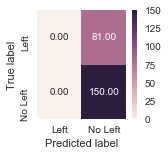

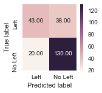

```python
type=["rbf","linear"]
for i in type:
    model=svm.SVC(kernel=i)
    model.fit(train_x, train_y)
    Pred_y=model.predict(test_x)
    print "Accuracy for svm kernel for ", i , "is : ", metrics.accuracy_score(test_y, Pred_y)
    cm=metrics.confusion_matrix(test_y, Pred_y,[1,0])
    plt.figure(figsize=(2,2))
    sns.heatmap(cm,annot=True, fmt=".2f",xticklabels = ["Left", "No Left"] , yticklabels = ["Left", "No Left"])
    plt.xlabel('Predicted label')
    plt.ylabel('True label')
    plt.plot()
```

### Logistic Regreesion

```
('The accuracy of the Logistic Regression is', 0.76190476190476186)
```

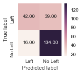

```python
model = LogisticRegression()
model.fit(train_x,train_y)
prediction=model.predict(test_x)
print('The accuracy of the Logistic Regression is',metrics.accuracy_score(prediction,test_y))
cm=metrics.confusion_matrix(test_y, prediction,[1,0])
plt.figure(figsize=(2,2))
sns.heatmap(cm,annot=True, fmt=".2f",xticklabels = ["Left", "No Left"] , yticklabels = ["Left", "No Left"])
plt.xlabel('Predicted label')
plt.ylabel('True label')
```

### Decision Tree

```python
model=DecisionTreeClassifier()
model.fit(train_x,train_y)
prediction=model.predict(test_x)
print('The accuracy of the Decision Tree is',metrics.accuracy_score(prediction,test_y))
```

```
('The accuracy of the Decision Tree is', 0.69264069264069261)
```

### K Nearest Neighbour

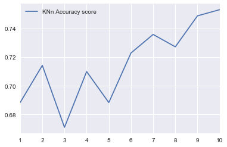

```python
a_index=list(range(1,11))
a=pd.Series()
b=[]
for i in range(1,11):
    model=KNeighborsClassifier(n_neighbors=i)
    model.fit(train_x, train_y)
    predict_y=model.predict(test_x)
    b.append(metrics.accuracy_score(test_y, predict_y))
b=pd.DataFrame(b,index=range(1,11))
b.columns=["KNn Accuracy score"]
b.plot()
```

### in a Null shell

```python
abc=[]
classifier=["Linear SVM","Radial SVM","Logistic Regression","KNN","decision tree"]
models=[svm.SVC(kernel='linear'), svm.SVC(kernel="rbf"),LogisticRegression(), KNeighborsClassifier(n_neighbors=3), DecisionTreeClassifier()]
for i in models:
    model=i
    model.fit(train_x,train_y)
    pred_y=model.predict(test_x)
    abc.append(metrics.accuracy_score(test_y,pred_y))
abc=pd.DataFrame(abc,index=classifier)
abc.columns=["Accuracy"]
abc
```

|  | Accuracy |
| --- | --- |
| Linear SVM | 0.748918 |
| Radial SVM | 0.649351 |
| Logistic Regression | 0.761905 |
| KNN | 0.670996 |
| decision tree | 0.692641 |

The above algorithms are not giving vey high accuracy. This can be improved by using Feature Selection and using only relevant features. We can also use ensembling or averaging of different algorithms. I will do these things in subsequent parts.

### co-relation matrics

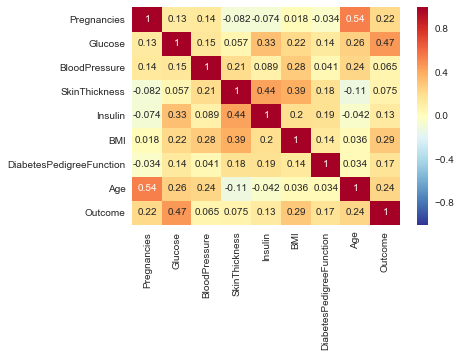

```python
sns.heatmap(diab.corr(), annot=True, cmap='RdYlBu_r')
```

### Random Forest classifier

```python
from sklearn.ensemble import RandomForestClassifier

rand_f=RandomForestClassifier(n_estimators=100 ,random_state=12)
rand_f.fit(train_x, train_y)
pd.Series(rand_f.feature_importances_,index=train_x.columns).sort_values(ascending=False)
```

```
Glucose                     0.264592
BMI                         0.173239
Age                         0.127926
DiabetesPedigreeFunction    0.122088
BloodPressure               0.086508
Pregnancies                 0.079334
Insulin                     0.074546
SkinThickness               0.071767
dtype: float64
```

### Observation

> - The important features are: Glucose, BMI, Age, DiabetesPedigreeFunction

### Standradsiation

There can be a lot of deviation in the given dataset. An example in the dataset can be the BMI where it has 248 unique values. This high variance has to be standardised.

#### Standardization is a useful technique to transform attributes with a Gaussian distribution and differing means and standard deviations to a standard Gaussian distribution with a mean of 0 and a standard deviation of 1.

### Using Only Important Features And Standardisation

```python
diab2=diab[['Glucose','BMI','Age','DiabetesPedigreeFunction','Outcome']]

from sklearn.preprocessing import StandardScaler

feature_column_2=diab2.columns.difference(['Outcome'])
feature_std=StandardScaler().fit_transform(diab2[feature_column_2])
x=pd.DataFrame(feature_std,columns=feature_column_2)
x["Outcome"]=diab2["Outcome"]

train_x, test_x, teain_y, test_t=train_test_split(x[feature_column_2],x["Outcome"],random_state=1, test_size=.3, stratify=x["Outcome"])

print "Train size x : ", train_x.shape, "y : ", train_y.shape
print "Test size x : ", test_x.shape, "y : ", test_y.shape
```

```
Train size x :  (537, 4) y :  (537L,)
Test size x :  (231, 4) y :  (231L,)
```

```python
new=[]
classifier=["Linear SVM","Radial SVM","Logistic Regression","KNN","decision tree"]
models=[svm.SVC(kernel='linear'), svm.SVC(kernel="rbf"),LogisticRegression(), KNeighborsClassifier(n_neighbors=3), DecisionTreeClassifier()]
for i in models:
    model=i
    model.fit(train_x,train_y)
    pred_y=model.predict(test_x)
    new.append(metrics.accuracy_score(test_y,pred_y))
new=pd.DataFrame(abc,index=classifier)
new.columns=["New Accuracy"]
new
```

|  | New Accuracy |
| --- | --- |
| Linear SVM | 0.748918 |
| Radial SVM | 0.649351 |
| Logistic Regression | 0.761905 |
| KNN | 0.670996 |
| decision tree | 0.692641 |

```python
new=new.merge(abc,left_index=True, right_index=True, how='left')
new["increase"]=new["New Accuracy"]-new["Accuracy"]
new
```

|  | New Accuracy | Accuracy | increase |
| --- | --- | --- | --- |
| Linear SVM | 0.748918 | 0.748918 | 0.0 |
| Radial SVM | 0.649351 | 0.649351 | 0.0 |
| Logistic Regression | 0.761905 | 0.761905 | 0.0 |
| KNN | 0.670996 | 0.670996 | 0.0 |
| decision tree | 0.692641 | 0.692641 | 0.0 |

```python
new.rename(columns={"New Accuracy" : "Standredize Accuracy"})
```

|  | Standredize Accuracy | Accuracy | increase |
| --- | --- | --- | --- |
| Linear SVM | 0.748918 | 0.748918 | 0.0 |
| Radial SVM | 0.649351 | 0.649351 | 0.0 |
| Logistic Regression | 0.761905 | 0.761905 | 0.0 |
| KNN | 0.670996 | 0.670996 | 0.0 |
| decision tree | 0.692641 | 0.692641 | 0.0 |

### Cross Validation

Many a times, the data is imbalanced, i.e there may be a high number of class1 instances but less number of other class instances. Thus we should train and test our algorithm on each and every instance of the dataset. Then we can take an average of all the noted accuracies over the dataset.

1)The K-Fold Cross Validation works by first dividing the dataset into k-subsets.

2)Let's say we divide the dataset into (k=5) parts. We reserve 1 part for testing and train the algorithm over the 4 parts.

3)We continue the process by changing the testing part in each iteration and training the algorithm over the other parts. The accuracies and errors are then averaged to get a average accuracy of the algorithm.

This is called K-Fold Cross Validation.

4)An algorithm may underfit over a dataset for some training data and sometimes also overfit the data for other training set. Thus with cross-validation, we can achieve a generalised model.

```python
from sklearn.model_selection import KFold
from sklearn.cross_validation import cross_val_score
```

```python
from sklearn.model_selection import KFold #for K-fold cross validation
from sklearn.model_selection import cross_val_score #score evaluation
```

```python
kfold = KFold(n_splits=20, random_state=22) # k=10, split the data into 10 equal parts
```

```python
XYZ=[]
Accuracy=[]
Classifier=["Linear SVM","Radial SVM","Logistic Regression","KNN","Decision Tree"]
models=[svm.SVC(kernel='linear'), svm.SVC(kernel='rbf'), LogisticRegression(), KNeighborsClassifier(n_neighbors=3), DecisionTreeClassifier()]

for i in models:
    model=i
    cv_score=cross_val_score(model,train_x,train_y, cv = 10, scoring= "accuracy")
    XYZ.append(cv_score.mean())
    Accuracy.append(cv_score)
new1=pd.DataFrame(XYZ, index=classifier)
new1.columns=["KFold Means"]
new1
```

|  | KFold Means |
| --- | --- |
| Linear SVM | 0.651817 |
| Radial SVM | 0.646226 |
| Logistic Regression | 0.649965 |
| KNN | 0.543606 |
| decision tree | 0.502865 |

```python
Accuracy1 = pd.DataFrame(Accuracy, index=[classifier])
```

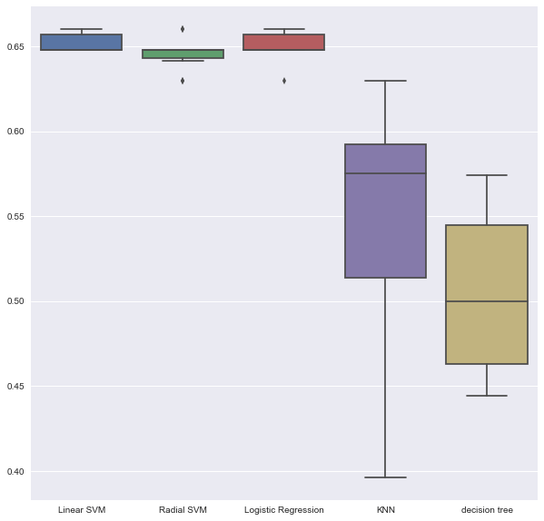

```python
plt.figure(figsize=(10,10))
sns.boxplot(Accuracy1.T)
```

[output not shown]

The above boxplot shows that SVM and LR perform the best while Decision Tree performs the worst.

### Ensembling

Ensemble methods are techniques that create multiple models and then combine them to produce improved results. Ensemble methods usually produces more accurate solutions than a single model would. The models used to create such ensemble models are called ‘base models’.

We will do ensembling with the Voting Ensemble. Voting is one of the simplest ways of combining the predictions from multiple machine learning algorithms. It works by first creating two or more standalone models from your training dataset. A Voting Classifier can then be used to wrap your models and average the predictions of the sub-models when asked to make predictions for new data.

We will be using weighted Voting Classifier. We will assign to the classifiers according to their accuracies. So the classifier with single accuracy will be assigned the highest weight and so on.

In our case, we will use the Top 3 classifiers i.e Linaer SVM, Radial(rbf) SVM and Logistic Regression classifiers.

```python
linear_svc=svm.SVC(kernel='linear',C=0.1,gamma=10,probability=True)
radial_svm=svm.SVC(kernel='rbf',C=0.1,gamma=10,probability=True)
lr=LogisticRegression(C=0.1)
```

```python
from sklearn.ensemble import VotingClassifier #for Voting Classifier
```

### Linear and Radial SVM

```python
ensembling_lin_rbf=VotingClassifier(estimators=[("Linear SVC", linear_svc),
                                                ("Radial SVM",radial_svm)],
                                    voting='soft', weights=[2,1]).fit(train_x,train_y)

print('The accuracy for Linear SVM and Logistic Regression is:',ensembling_lin_rbf.score(test_x,test_y))
```

[output not shown]

```python
ensemble_lin_lr=VotingClassifier(estimators=[('Linear_svm', linear_svc), ('Logistic Regression', lr)],
                       voting='soft', weights=[2,1]).fit(train_x,train_y)
print('The accuracy for Linear SVM and Logistic Regression is:',ensemble_lin_lr.score(test_x,test_y))
```

```
('The accuracy for Linear SVM and Logistic Regression is:', 0.64935064935064934)
```

```python
ensemble_rad_lr=VotingClassifier(estimators=[('Radial_svm', radial_svm), ('Logistic Regression', lr)],
                       voting='soft', weights=[2,1]).fit(train_x,train_y)
print('The accuracy for Radial SVM and Logistic Regression is:',ensemble_rad_lr.score(test_x,test_y))
```

```
('The accuracy for Radial SVM and Logistic Regression is:', 0.64935064935064934)
```

```python
ensemble_rad_lr_lin=VotingClassifier(estimators=[('Radial_svm', radial_svm), ('Logistic Regression', lr),('Linear_svm',linear_svc)],
                       voting='soft', weights=[3,2,1]).fit(train_x,train_y)
print('The ensembled model with all the 3 classifiers is:',ensemble_rad_lr_lin.score(test_x,test_y))
```

```
('The ensembled model with all the 3 classifiers is:', 0.64935064935064934)
```